# Pay to Play: College Athletics Spending and Success Before NIL

STOR 320.02 Group 15

April 28, 2025

# INTRODUCTION

College football is a multi-billion-dollar industry where schools invest heavily in hopes of winning games, building national prestige, attracting students, and strengthening alumni ties. Yet despite the widespread belief in the “spend to win” model, it remains unclear whether simply spending more actually guarantees greater success — especially when considering the wide differences in academic reputation, enrollment size, and conference affiliation among universities.

While powerhouse programs like those in the “Power Five” conferences tend to dominate both financially and competitively, many questions remain. Which types of investments — such as coaching salaries, recruiting budgets, or football operations — actually matter most? Does money have the same impact at highly ranked academic schools compared to others? And how do different revenue streams like ticket sales or athletic aid shape a team’s investment strategy and, ultimately, its success?

**This project explores two main questions:**

- **First**, to what extent do financial investments predict college football success across different conferences, and how does this relationship vary by a university’s academic level and size?
- **Second**, how do differences in football success and athletic revenue affect the composition of athletic investment strategy by universities that differ by competitive level?

Answering these questions matters now more than ever. As the college sports world rapidly shifts in the wake of NIL policies, understanding how money shaped success in the pre-NIL era provides an important baseline. This research also offers insights for smaller programs trying to do more with less — and for bigger programs questioning whether their massive spending truly pays off. Moving beyond the simple “more money equals more wins” narrative, this study aims to uncover a more complete picture of what drives success in college football and financially for the overall athletic department.

# DATA

The information utilized for this project was mostly obtained from Sports Viz Sunday, which is edited by Simon Beaumont and Spencer Baucke, and provided by Data World. This data set provided both NCAA financial information—revenue, spending, and highest-investing categories—and football performance data such as wins, losses, and win percentage for Division I institutions between 2005 and 2017. Admissions and academic data, including the number of students enrolled and institution types, were obtained separately from the U.S. Department of Education’s College Scorecard database, which pulls together extensive details on colleges nationally. We decided to look at the 2005–2017 years in order to include trends before Name, Image, and Likeness (NIL) policies were implemented, so the financial and competitive trends examined would represent the pre-NIL era of traditional collegiate athletics before direct athlete compensation became prevalent.

To examine the association between financial investment and sports success, we combined NCAA financial data and football performance statistics for the period between 2005 and 2017. The significant financial variables included Total Revenues, Total Expenses, Coaches Compensation, Facilities and Equipment spending, Athletic Student Aid, Game Expenses and Travel, Donor Contributions, Recruiting, and more. These investment sources were chosen because they both represent internal program decision-making on expenditures and external sources of funding significant to a program’s growth. On the performance side, football-specific metrics such as Wins, Losses, and Winning Percentage were used, since football disproportionately contributes to overall athletic revenue at most universities. To more fully control for structural variation across programs, schools were grouped into High-Major, Mid-Major, and Low-Major categories based on football conference affiliation, using only conferences that remained intact over the study period (with independent schools and discontinued conferences like the Big East and WAC excluded). Academic controls, such as undergraduate enrollment and football spending normalized per student, were further added to consider investment trends by institutional academic type. Together, the variables selected provided an overall profile of how competitive greatness, financial efforts, scholarly emphasis, and top-line revenue generation relate to the collegiate athletic scene.

[figure not shown]

NCAA Financial Metrics Over the Years  
by Conference Group

2005 - 2017 (Pre-NIL)

Conference Group

Average Totals<sup>1</sup>

Avg % Growth per Year

Trends

Expenses

Coaching Salaries

Recruiting

Expenses

Coaching Salaries

Recruiting

Expenses

Revenue

High-Major

90.41

6.30

1.43

5.28

7.37

5.31

Mid-Major

69.49

5.07

1.14

4.31

7.15

3.66

Low-Major

28.26

2.02

0.51

3.58

3.85

2.93

<sup>1</sup> *In Millions of Dollars*

This table shows NCAA conference groups’ patterns of financial investment in university athletics across all sports from 2005 to 2017, prior to the NIL era. Schools were placed into High-Major, Mid-Major, and Low-Major categories based on football conference affiliation, with independents (schools without a football conference affiliation) not included for consideration. The table provides averages and average annual percentage changes in total expenses, coaching salaries, and recruiting expenses, as well as trendlines for expenses and revenues. The clear conclusion is that High-Major programs spent the most in each category, experienced the highest rate of growth, and generated considerably more revenue than Mid-Major and Low-Major programs. This speaks to the colossal conference level budget differences and suggests that variation in financial resources is a fundamental driver of long-run competitive and financial outcomes across college athletics.

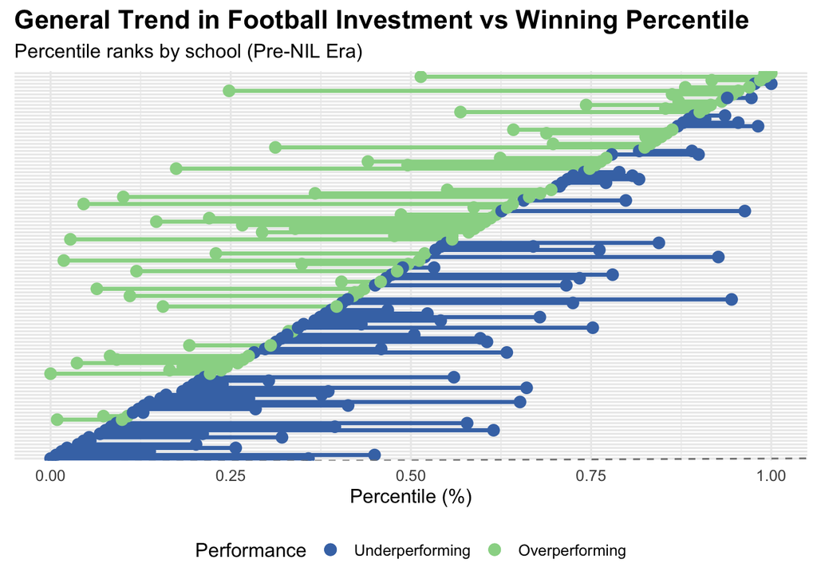

# RESULTS

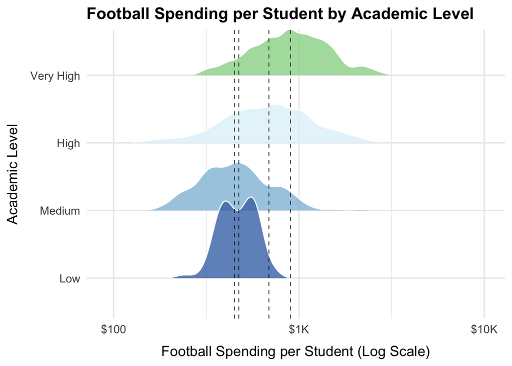

We built a ridgeline density plot to explore variance in football expenditure across institutions of varying academic quality, normalizing by undergraduate enrollment to create a “Football Spending Per Student” variable. To better visualize differences across schools with highly skewed budgets, we applied a log transformation. Institutions were classified into four academic levels based on median ACT scores: “Low” (approximately the 30th percentile), “Medium” (50th to 65th percentile), “High” (70th to 85th percentile), and “Very High” (90th percentile and above). To provide emphasis points, median expenditure lines were overlaid. The plot reveals a clear positive correlation between academic selectivity and football investment, with “Very High” academic institutions spending significantly more per student. Although the distributions generally shift to the right with higher academic levels, noticeable overlap remains, particularly among “Medium” and “High” categories. This indicates that while stronger academic reputation tends to correspond with greater football investment, other factors such as conference affiliation, donor contributions, and ticket sales also play substantial roles in shaping football expenditures.

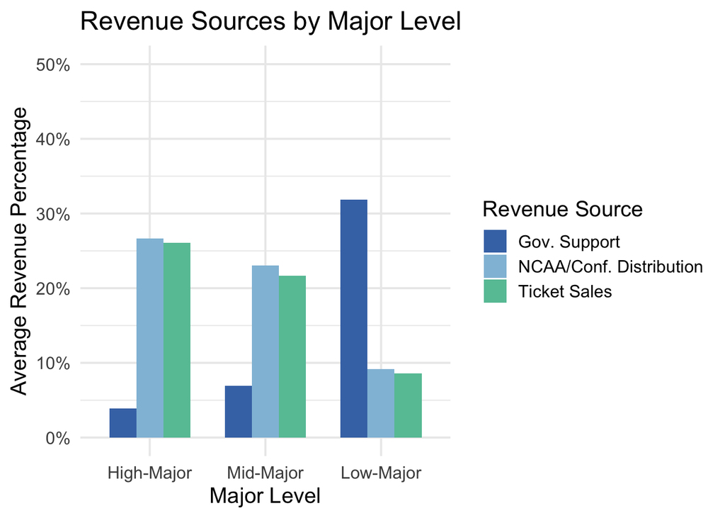

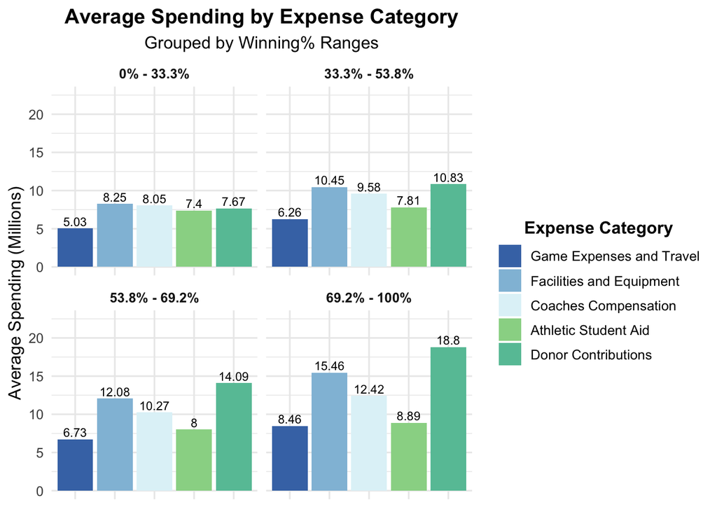

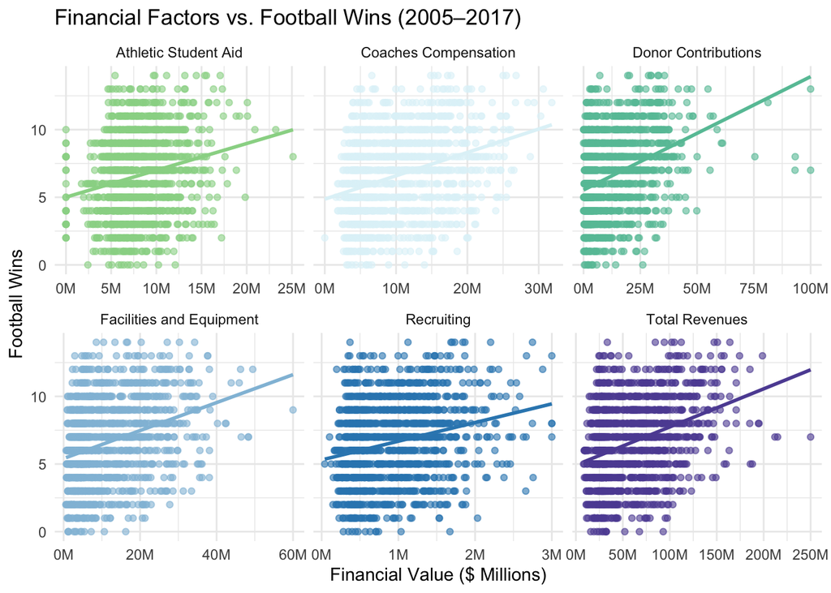

# CONCLUSION

These results are highly relevant to everyday life, especially with college sports economics still up in the air following NIL. They confirm that while money matters, where money is being spent is still more critical. Sports programs aiming to maximize competitive success should spend money on durable goods like facilities and creating donor bases at the expense of merely raising pay. This has significant implications for programs with limited resources: rather than simply trying to outspend rivals in every category, schools can concentrate on certain fiscal approaches to enhance competitiveness. Similarly, university administrators, policymakers, and donors should be interested in these results because they show that smarter, more strategic investment—not just bigger budgets—is the key to long-term athletic and fiscal success.

Subsequent research could expand on this paper by employing more current NIL-related financial data and experimenting with other variables like individual player performance, transfer portal matrices, or academic support investments. Access to richer data sets involving more granular fundraising by sport, alumni involvement scores, or the age and quality of athletic facilities would allow even more accurate modeling. More advanced machine learning techniques like gradient boosting or random forests might also be able to better identify non-linear correlations between expenditure and success that might elude more basic linear models.

Overall, the results largely upheld what was anticipated—money matters, but wiser spending matters even more. However, the strength of the results, particularly how well donor giving predicted success compared to other forms of investment, was quite unexpected. With college athletics entering an era of increased professionalization, these results will remain vital to programs at all levels seeking to balance fiscal adversity with competitiveness on the playing field.